# act_report

## Report: act_report

## WeRateDogs Analysis Insights

### Research Question 1: What is the most popular dog breed

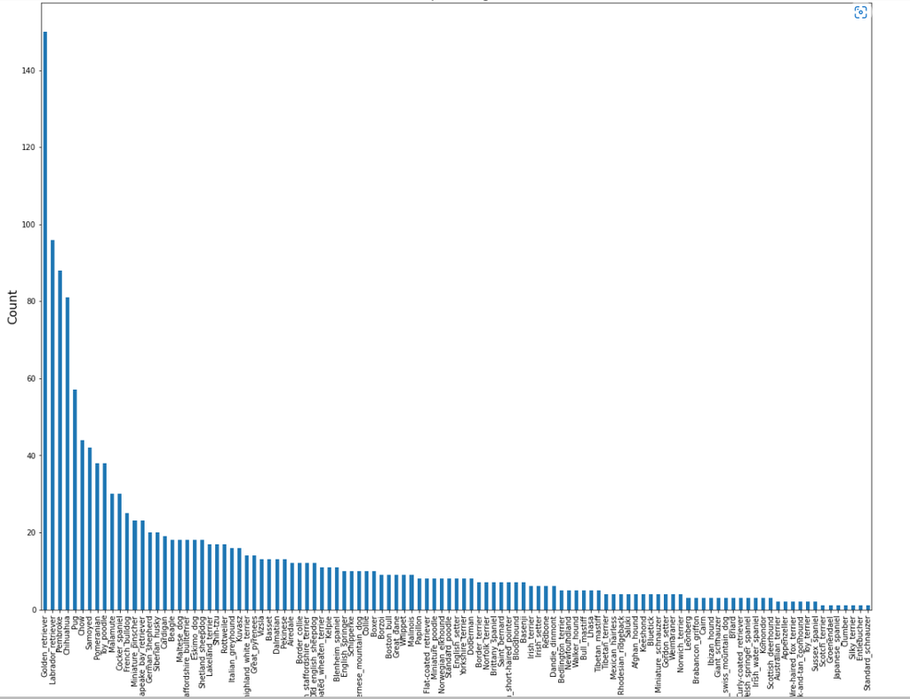

**Insight**: Golden Retriever is the most popular breed or most owned dog breed as shown in the visualization above

### Research Question 2: What are most common names given to dogs

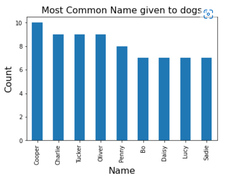

From the above image, we can deduce that "Cooper" is the most common name given to dogs, This can be better visualized with a Wordcloud

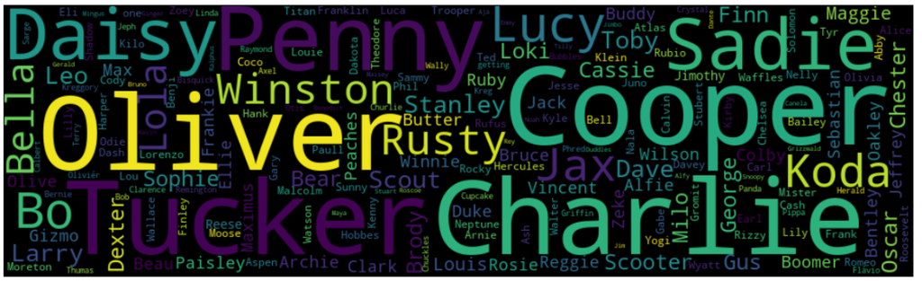

**Insight**: "Cooper" is the most common dog name, followed by "charlie"

### Research Question 3: What is the most often and lowest rating given to dogs

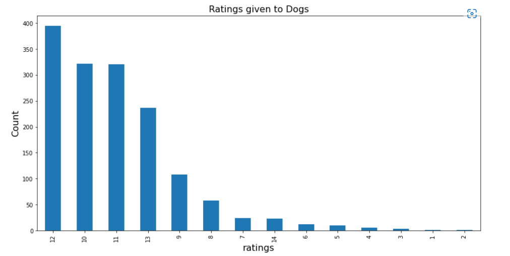

**Insight**: Ratings 12/10 is most often given to dogs while 2/10 is the least given to dogs

We also proceeded to examine why a dog got 2/10 rating

> Crystal, a Maltese dog breed got a 2/10 rating and we proceeded to have a visual assessment as to why

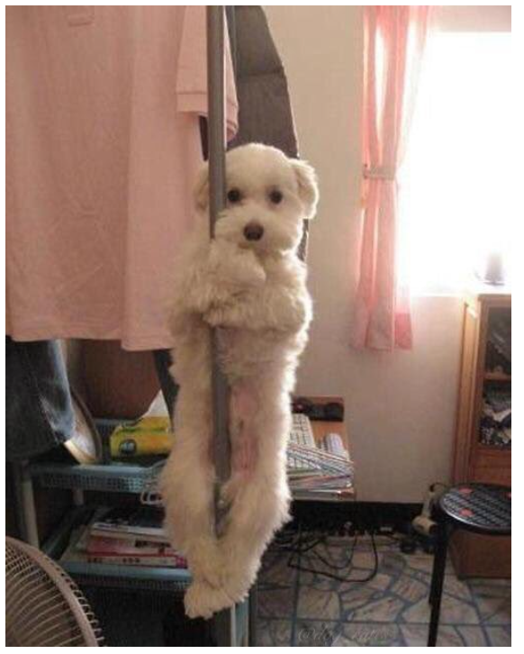

Above is a picture of Crystal, with the tweet text

"This is Crystal. She's a shitty fireman. No sense of urgency. People could be dying Crystal. 2/10 just irresponsible "

A bit harsh, Lol. Because Crystal look like a "firedog" i would 80% trust with my life, would give her 13/10 if i could

### Research Question 4: Which post has the highest likes and retweet of all time

We began answering this quesstion by quering the dataframe to return the highest like and retweet count we have.

Turns out it belonged to the same dog

Although, our superstar's name wasnt mentioned in the tweet text;

"Here's a doggo realizing you can stand in a pool. enlightened af (vid by Tina Conrad) "

> Below is The picture of our nameless Superstar

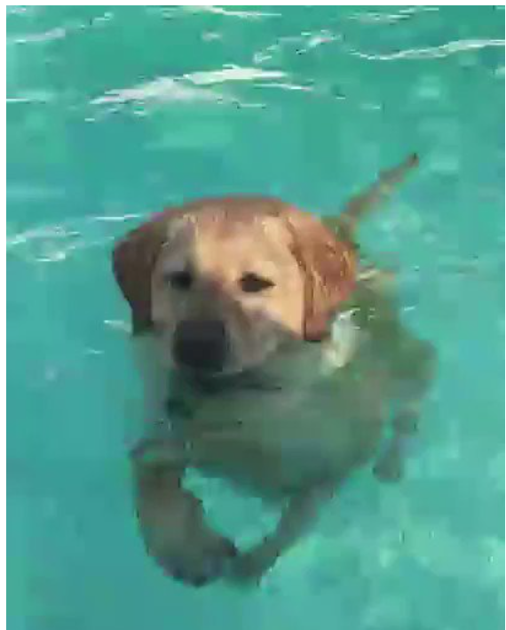

**Insight**: People Love a swimming dog : )

### Bonus Visualization

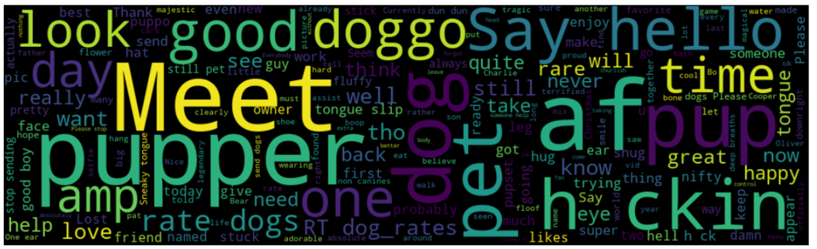

Above is a WordCloud visualization of all the words in the "text" column of the dataframe. We can see occuring words like meet, pupper e.t.c